# W3cubDocs

/GTK 3.24

# GtkScrolledWindow

GtkScrolledWindow — Adds scrollbars to its child widget

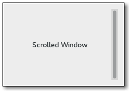

## Functions

| GtkWidget * | gtk_scrolled_window_new () |
| --- | --- |
| GtkAdjustment * | gtk_scrolled_window_get_hadjustment () |
| void | gtk_scrolled_window_set_hadjustment () |
| GtkAdjustment * | gtk_scrolled_window_get_vadjustment () |
| void | gtk_scrolled_window_set_vadjustment () |
| GtkWidget * | gtk_scrolled_window_get_hscrollbar () |
| GtkWidget * | gtk_scrolled_window_get_vscrollbar () |
| void | gtk_scrolled_window_get_policy () |
| void | gtk_scrolled_window_set_policy () |
| void | gtk_scrolled_window_add_with_viewport () |
| GtkCornerType | gtk_scrolled_window_get_placement () |
| void | gtk_scrolled_window_set_placement () |
| void | gtk_scrolled_window_unset_placement () |
| GtkShadowType | gtk_scrolled_window_get_shadow_type () |
| void | gtk_scrolled_window_set_shadow_type () |
| gboolean | gtk_scrolled_window_get_kinetic_scrolling () |
| void | gtk_scrolled_window_set_kinetic_scrolling () |
| gboolean | gtk_scrolled_window_get_capture_button_press () |
| void | gtk_scrolled_window_set_capture_button_press () |
| gboolean | gtk_scrolled_window_get_overlay_scrolling () |
| void | gtk_scrolled_window_set_overlay_scrolling () |
| gint | gtk_scrolled_window_get_min_content_width () |
| void | gtk_scrolled_window_set_min_content_width () |
| gint | gtk_scrolled_window_get_min_content_height () |
| void | gtk_scrolled_window_set_min_content_height () |
| gint | gtk_scrolled_window_get_max_content_width () |
| void | gtk_scrolled_window_set_max_content_width () |
| gint | gtk_scrolled_window_get_max_content_height () |
| void | gtk_scrolled_window_set_max_content_height () |
| gboolean | gtk_scrolled_window_get_propagate_natural_width () |
| void | gtk_scrolled_window_set_propagate_natural_width () |
| gboolean | gtk_scrolled_window_get_propagate_natural_height () |
| void | gtk_scrolled_window_set_propagate_natural_height () |

## Properties

| GtkAdjustment * | hadjustment | Read / Write / Construct |
| --- | --- | --- |
| GtkPolicyType | hscrollbar-policy | Read / Write |
| gboolean | kinetic-scrolling | Read / Write |
| int | max-content-height | Read / Write |
| int | max-content-width | Read / Write |
| int | min-content-height | Read / Write |
| int | min-content-width | Read / Write |
| gboolean | overlay-scrolling | Read / Write |
| gboolean | propagate-natural-height | Read / Write |
| gboolean | propagate-natural-width | Read / Write |
| GtkShadowType | shadow-type | Read / Write |
| GtkAdjustment * | vadjustment | Read / Write / Construct |
| GtkPolicyType | vscrollbar-policy | Read / Write |
| GtkCornerType | window-placement | Read / Write |
| gboolean | window-placement-set | Read / Write |

## Style Properties

| int | scrollbar-spacing | Read |
| --- | --- | --- |
| gboolean | scrollbars-within-bevel | Read |

## Signals

| void | edge-overshot | Run Last |
| --- | --- | --- |
| void | edge-reached | Run Last |
| void | move-focus-out | Action |
| gboolean | scroll-child | Action |

## Types and Values

| struct | GtkScrolledWindow |
| --- | --- |
| struct | GtkScrolledWindowClass |
| enum | GtkPolicyType |
| enum | GtkCornerType |

## Object Hierarchy

```
    GObject
    ╰── GInitiallyUnowned
        ╰── GtkWidget
            ╰── GtkContainer
                ╰── GtkBin
                    ╰── GtkScrolledWindow
                        ╰── GtkPlacesSidebar
```

## Implemented Interfaces

GtkScrolledWindow implements AtkImplementorIface and GtkBuildable.

## Includes

```
#include <gtk/gtk.h>
```

## Description

GtkScrolledWindow is a container that accepts a single child widget, makes that child scrollable using either internally added scrollbars or externally associated adjustments, and optionally draws a frame around the child.

Widgets with native scrolling support, i.e. those whose classes implement the GtkScrollable interface, are added directly. For other types of widget, the class GtkViewport acts as an adaptor, giving scrollability to other widgets. GtkScrolledWindow’s implementation of `gtk_container_add()` intelligently accounts for whether or not the added child is a GtkScrollable. If it isn’t, GtkScrolledWindow wraps the child in a GtkViewport and adds that for you. Therefore, you can just add any child widget and not worry about the details.

If `gtk_container_add()` has added a GtkViewport for you, you can remove both your added child widget from the GtkViewport, and the GtkViewport from the GtkScrolledWindow, like this:

```
GtkWidget *scrolled_window = gtk_scrolled_window_new (NULL, NULL);
GtkWidget *child_widget = gtk_button_new ();

// GtkButton is not a GtkScrollable, so GtkScrolledWindow will automatically
// add a GtkViewport.
gtk_container_add (GTK_CONTAINER (scrolled_window),
                   child_widget);

// Either of these will result in child_widget being unparented:
gtk_container_remove (GTK_CONTAINER (scrolled_window),
                      child_widget);
// or
gtk_container_remove (GTK_CONTAINER (scrolled_window),
                      gtk_bin_get_child (GTK_BIN (scrolled_window)));
```

Unless “policy” is GTK_POLICY_NEVER or GTK_POLICY_EXTERNAL, GtkScrolledWindow adds internal GtkScrollbar widgets around its child. The scroll position of the child, and if applicable the scrollbars, is controlled by the “hadjustment” and “vadjustment” that are associated with the GtkScrolledWindow. See the docs on GtkScrollbar for the details, but note that the “step_increment” and “page_increment” fields are only effective if the policy causes scrollbars to be present.

If a GtkScrolledWindow doesn’t behave quite as you would like, or doesn’t have exactly the right layout, it’s very possible to set up your own scrolling with GtkScrollbar and for example a GtkGrid.

### Touch support

GtkScrolledWindow has built-in support for touch devices. When a touchscreen is used, swiping will move the scrolled window, and will expose 'kinetic' behavior. This can be turned off with the “kinetic-scrolling” property if it is undesired.

GtkScrolledWindow also displays visual 'overshoot' indication when the content is pulled beyond the end, and this situation can be captured with the “edge-overshot” signal.

If no mouse device is present, the scrollbars will overlayed as narrow, auto-hiding indicators over the content. If traditional scrollbars are desired although no mouse is present, this behaviour can be turned off with the “overlay-scrolling” property.

### CSS nodes

GtkScrolledWindow has a main CSS node with name scrolledwindow.

It uses subnodes with names overshoot and undershoot to draw the overflow and underflow indications. These nodes get the .left, .right, .top or .bottom style class added depending on where the indication is drawn.

GtkScrolledWindow also sets the positional style classes (.left, .right, .top, .bottom) and style classes related to overlay scrolling (.overlay-indicator, .dragging, .hovering) on its scrollbars.

If both scrollbars are visible, the area where they meet is drawn with a subnode named junction.

## Functions

### gtk_scrolled_window_new ()

```
GtkWidget *
gtk_scrolled_window_new (GtkAdjustment *hadjustment,
                         GtkAdjustment *vadjustment);
```

Creates a new scrolled window.

The two arguments are the scrolled window’s adjustments; these will be shared with the scrollbars and the child widget to keep the bars in sync with the child. Usually you want to pass `NULL` for the adjustments, which will cause the scrolled window to create them for you.

#### Parameters

| hadjustment | horizontal adjustment. | [nullable] |
| --- | --- | --- |
| vadjustment | vertical adjustment. | [nullable] |

#### Returns

a new scrolled window

### gtk_scrolled_window_get_hadjustment ()

```
GtkAdjustment *
gtk_scrolled_window_get_hadjustment (GtkScrolledWindow *scrolled_window);
```

Returns the horizontal scrollbar’s adjustment, used to connect the horizontal scrollbar to the child widget’s horizontal scroll functionality.

#### Parameters

| scrolled_window | a GtkScrolledWindow |  |
| --- | --- | --- |

#### Returns

the horizontal GtkAdjustment.

[transfer none]

### gtk_scrolled_window_set_hadjustment ()

```
void
gtk_scrolled_window_set_hadjustment (GtkScrolledWindow *scrolled_window,
                                     GtkAdjustment *hadjustment);
```

Sets the GtkAdjustment for the horizontal scrollbar.

#### Parameters

| scrolled_window | a GtkScrolledWindow |  |
| --- | --- | --- |
| hadjustment | the GtkAdjustment to use, or `NULL` to create a new one. | [nullable] |

### gtk_scrolled_window_get_vadjustment ()

```
GtkAdjustment *
gtk_scrolled_window_get_vadjustment (GtkScrolledWindow *scrolled_window);
```

Returns the vertical scrollbar’s adjustment, used to connect the vertical scrollbar to the child widget’s vertical scroll functionality.

#### Parameters

| scrolled_window | a GtkScrolledWindow |  |
| --- | --- | --- |

#### Returns

the vertical GtkAdjustment.

[transfer none]

### gtk_scrolled_window_set_vadjustment ()

```
void
gtk_scrolled_window_set_vadjustment (GtkScrolledWindow *scrolled_window,
                                     GtkAdjustment *vadjustment);
```

Sets the GtkAdjustment for the vertical scrollbar.

#### Parameters

| scrolled_window | a GtkScrolledWindow |  |
| --- | --- | --- |
| vadjustment | the GtkAdjustment to use, or `NULL` to create a new one. | [nullable] |

### gtk_scrolled_window_get_hscrollbar ()

```
GtkWidget *
gtk_scrolled_window_get_hscrollbar (GtkScrolledWindow *scrolled_window);
```

Returns the horizontal scrollbar of *`scrolled_window`* .

#### Parameters

| scrolled_window | a GtkScrolledWindow |  |
| --- | --- | --- |

#### Returns

the horizontal scrollbar of the scrolled window.

[transfer none]

Since: 2.8

### gtk_scrolled_window_get_vscrollbar ()

```
GtkWidget *
gtk_scrolled_window_get_vscrollbar (GtkScrolledWindow *scrolled_window);
```

Returns the vertical scrollbar of *`scrolled_window`* .

#### Parameters

| scrolled_window | a GtkScrolledWindow |  |
| --- | --- | --- |

#### Returns

the vertical scrollbar of the scrolled window.

[transfer none]

Since: 2.8

### gtk_scrolled_window_get_policy ()

```
void
gtk_scrolled_window_get_policy (GtkScrolledWindow *scrolled_window,
                                GtkPolicyType *hscrollbar_policy,
                                GtkPolicyType *vscrollbar_policy);
```

Retrieves the current policy values for the horizontal and vertical scrollbars. See `gtk_scrolled_window_set_policy()`.

#### Parameters

| scrolled_window | a GtkScrolledWindow |  |
| --- | --- | --- |
| hscrollbar_policy | location to store the policy for the horizontal scrollbar, or `NULL`. | [out][optional] |
| vscrollbar_policy | location to store the policy for the vertical scrollbar, or `NULL`. | [out][optional] |

### gtk_scrolled_window_set_policy ()

```
void
gtk_scrolled_window_set_policy (GtkScrolledWindow *scrolled_window,
                                GtkPolicyType hscrollbar_policy,
                                GtkPolicyType vscrollbar_policy);
```

Sets the scrollbar policy for the horizontal and vertical scrollbars.

The policy determines when the scrollbar should appear; it is a value from the GtkPolicyType enumeration. If `GTK_POLICY_ALWAYS`, the scrollbar is always present; if `GTK_POLICY_NEVER`, the scrollbar is never present; if `GTK_POLICY_AUTOMATIC`, the scrollbar is present only if needed (that is, if the slider part of the bar would be smaller than the trough — the display is larger than the page size).

#### Parameters

| scrolled_window | a GtkScrolledWindow |  |
| --- | --- | --- |
| hscrollbar_policy | policy for horizontal bar |  |
| vscrollbar_policy | policy for vertical bar |  |

### gtk_scrolled_window_add_with_viewport ()

```
void
gtk_scrolled_window_add_with_viewport (GtkScrolledWindow *scrolled_window,
                                       GtkWidget *child);
```

`gtk_scrolled_window_add_with_viewport` has been deprecated since version 3.8 and should not be used in newly-written code.

gtk_container_add() will automatically add a GtkViewport if the child doesn’t implement GtkScrollable.

Used to add children without native scrolling capabilities. This is simply a convenience function; it is equivalent to adding the unscrollable child to a viewport, then adding the viewport to the scrolled window. If a child has native scrolling, use `gtk_container_add()` instead of this function.

The viewport scrolls the child by moving its [GdkWindow](https://developer.gnome.org/gtk3/html/gdk3-Windows.html#GdkWindow-struct), and takes the size of the child to be the size of its toplevel [GdkWindow](https://developer.gnome.org/gtk3/html/gdk3-Windows.html#GdkWindow-struct). This will be very wrong for most widgets that support native scrolling; for example, if you add a widget such as GtkTreeView with a viewport, the whole widget will scroll, including the column headings. Thus, widgets with native scrolling support should not be used with the GtkViewport proxy.

A widget supports scrolling natively if it implements the GtkScrollable interface.

#### Parameters

| scrolled_window | a GtkScrolledWindow |  |
| --- | --- | --- |
| child | the widget you want to scroll |  |

### gtk_scrolled_window_get_placement ()

```
GtkCornerType
gtk_scrolled_window_get_placement (GtkScrolledWindow *scrolled_window);
```

Gets the placement of the contents with respect to the scrollbars for the scrolled window. See `gtk_scrolled_window_set_placement()`.

#### Parameters

| scrolled_window | a GtkScrolledWindow |  |
| --- | --- | --- |

#### Returns

the current placement value.

See also `gtk_scrolled_window_set_placement()` and `gtk_scrolled_window_unset_placement()`.

### gtk_scrolled_window_set_placement ()

```
void
gtk_scrolled_window_set_placement (GtkScrolledWindow *scrolled_window,
                                   GtkCornerType window_placement);
```

Sets the placement of the contents with respect to the scrollbars for the scrolled window.

The default is `GTK_CORNER_TOP_LEFT`, meaning the child is in the top left, with the scrollbars underneath and to the right. Other values in GtkCornerType are `GTK_CORNER_TOP_RIGHT`, `GTK_CORNER_BOTTOM_LEFT`, and `GTK_CORNER_BOTTOM_RIGHT`.

See also `gtk_scrolled_window_get_placement()` and `gtk_scrolled_window_unset_placement()`.

#### Parameters

| scrolled_window | a GtkScrolledWindow |  |
| --- | --- | --- |
| window_placement | position of the child window |  |

### gtk_scrolled_window_unset_placement ()

```
void
gtk_scrolled_window_unset_placement (GtkScrolledWindow *scrolled_window);
```

Unsets the placement of the contents with respect to the scrollbars for the scrolled window. If no window placement is set for a scrolled window, it defaults to `GTK_CORNER_TOP_LEFT`.

See also `gtk_scrolled_window_set_placement()` and `gtk_scrolled_window_get_placement()`.

#### Parameters

| scrolled_window | a GtkScrolledWindow |  |
| --- | --- | --- |

Since: 2.10

### gtk_scrolled_window_get_shadow_type ()

```
GtkShadowType
gtk_scrolled_window_get_shadow_type (GtkScrolledWindow *scrolled_window);
```

Gets the shadow type of the scrolled window. See `gtk_scrolled_window_set_shadow_type()`.

#### Parameters

| scrolled_window | a GtkScrolledWindow |  |
| --- | --- | --- |

#### Returns

the current shadow type

### gtk_scrolled_window_set_shadow_type ()

```
void
gtk_scrolled_window_set_shadow_type (GtkScrolledWindow *scrolled_window,
                                     GtkShadowType type);
```

Changes the type of shadow drawn around the contents of *`scrolled_window`* .

#### Parameters

| scrolled_window | a GtkScrolledWindow |  |
| --- | --- | --- |
| type | kind of shadow to draw around scrolled window contents |  |

### gtk_scrolled_window_get_kinetic_scrolling ()

```
gboolean
gtk_scrolled_window_get_kinetic_scrolling
                               (GtkScrolledWindow *scrolled_window);
```

Returns the specified kinetic scrolling behavior.

#### Parameters

| scrolled_window | a GtkScrolledWindow |  |
| --- | --- | --- |

#### Returns

the scrolling behavior flags.

Since: 3.4

### gtk_scrolled_window_set_kinetic_scrolling ()

```
void
gtk_scrolled_window_set_kinetic_scrolling
                               (GtkScrolledWindow *scrolled_window,
                                gboolean kinetic_scrolling);
```

Turns kinetic scrolling on or off. Kinetic scrolling only applies to devices with source [`GDK_SOURCE_TOUCHSCREEN`](https://developer.gnome.org/gtk3/html/GdkDevice.html#GDK-SOURCE-TOUCHSCREEN:CAPS).

#### Parameters

| scrolled_window | a GtkScrolledWindow |  |
| --- | --- | --- |
| kinetic_scrolling | `TRUE` to enable kinetic scrolling |  |

Since: 3.4

### gtk_scrolled_window_get_capture_button_press ()

```
gboolean
gtk_scrolled_window_get_capture_button_press
                               (GtkScrolledWindow *scrolled_window);
```

Return whether button presses are captured during kinetic scrolling. See `gtk_scrolled_window_set_capture_button_press()`.

#### Parameters

| scrolled_window | a GtkScrolledWindow |  |
| --- | --- | --- |

#### Returns

`TRUE` if button presses are captured during kinetic scrolling

Since: 3.4

### gtk_scrolled_window_set_capture_button_press ()

```
void
gtk_scrolled_window_set_capture_button_press
                               (GtkScrolledWindow *scrolled_window,
                                gboolean capture_button_press);
```

Changes the behaviour of *`scrolled_window`* with regard to the initial event that possibly starts kinetic scrolling. When *`capture_button_press`* is set to `TRUE`, the event is captured by the scrolled window, and then later replayed if it is meant to go to the child widget.

This should be enabled if any child widgets perform non-reversible actions on “button-press-event”. If they don't, and handle additionally handle “grab-broken-event”, it might be better to set *`capture_button_press`* to `FALSE`.

This setting only has an effect if kinetic scrolling is enabled.

#### Parameters

| scrolled_window | a GtkScrolledWindow |  |
| --- | --- | --- |
| capture_button_press | `TRUE` to capture button presses |  |

Since: 3.4

### gtk_scrolled_window_get_overlay_scrolling ()

```
gboolean
gtk_scrolled_window_get_overlay_scrolling
                               (GtkScrolledWindow *scrolled_window);
```

Returns whether overlay scrolling is enabled for this scrolled window.

#### Parameters

| scrolled_window | a GtkScrolledWindow |  |
| --- | --- | --- |

#### Returns

`TRUE` if overlay scrolling is enabled

Since: 3.16

### gtk_scrolled_window_set_overlay_scrolling ()

```
void
gtk_scrolled_window_set_overlay_scrolling
                               (GtkScrolledWindow *scrolled_window,
                                gboolean overlay_scrolling);
```

Enables or disables overlay scrolling for this scrolled window.

#### Parameters

| scrolled_window | a GtkScrolledWindow |  |
| --- | --- | --- |
| overlay_scrolling | whether to enable overlay scrolling |  |

Since: 3.16

### gtk_scrolled_window_get_min_content_width ()

```
gint
gtk_scrolled_window_get_min_content_width
                               (GtkScrolledWindow *scrolled_window);
```

Gets the minimum content width of *`scrolled_window`* , or -1 if not set.

#### Parameters

| scrolled_window | a GtkScrolledWindow |  |
| --- | --- | --- |

#### Returns

the minimum content width

Since: 3.0

### gtk_scrolled_window_set_min_content_width ()

```
void
gtk_scrolled_window_set_min_content_width
                               (GtkScrolledWindow *scrolled_window,
                                gint width);
```

Sets the minimum width that *`scrolled_window`* should keep visible. Note that this can and (usually will) be smaller than the minimum size of the content.

It is a programming error to set the minimum content width to a value greater than “max-content-width”.

#### Parameters

| scrolled_window | a GtkScrolledWindow |  |
| --- | --- | --- |
| width | the minimal content width |  |

Since: 3.0

### gtk_scrolled_window_get_min_content_height ()

```
gint
gtk_scrolled_window_get_min_content_height
                               (GtkScrolledWindow *scrolled_window);
```

Gets the minimal content height of *`scrolled_window`* , or -1 if not set.

#### Parameters

| scrolled_window | a GtkScrolledWindow |  |
| --- | --- | --- |

#### Returns

the minimal content height

Since: 3.0

### gtk_scrolled_window_set_min_content_height ()

```
void
gtk_scrolled_window_set_min_content_height
                               (GtkScrolledWindow *scrolled_window,
                                gint height);
```

Sets the minimum height that *`scrolled_window`* should keep visible. Note that this can and (usually will) be smaller than the minimum size of the content.

It is a programming error to set the minimum content height to a value greater than “max-content-height”.

#### Parameters

| scrolled_window | a GtkScrolledWindow |  |
| --- | --- | --- |
| height | the minimal content height |  |

Since: 3.0

### gtk_scrolled_window_get_max_content_width ()

```
gint
gtk_scrolled_window_get_max_content_width
                               (GtkScrolledWindow *scrolled_window);
```

Returns the maximum content width set.

#### Parameters

| scrolled_window | a GtkScrolledWindow |  |
| --- | --- | --- |

#### Returns

the maximum content width, or -1

Since: 3.22

### gtk_scrolled_window_set_max_content_width ()

```
void
gtk_scrolled_window_set_max_content_width
                               (GtkScrolledWindow *scrolled_window,
                                gint width);
```

Sets the maximum width that *`scrolled_window`* should keep visible. The *`scrolled_window`* will grow up to this width before it starts scrolling the content.

It is a programming error to set the maximum content width to a value smaller than “min-content-width”.

#### Parameters

| scrolled_window | a GtkScrolledWindow |  |
| --- | --- | --- |
| width | the maximum content width |  |

Since: 3.22

### gtk_scrolled_window_get_max_content_height ()

```
gint
gtk_scrolled_window_get_max_content_height
                               (GtkScrolledWindow *scrolled_window);
```

Returns the maximum content height set.

#### Parameters

| scrolled_window | a GtkScrolledWindow |  |
| --- | --- | --- |

#### Returns

the maximum content height, or -1

Since: 3.22

### gtk_scrolled_window_set_max_content_height ()

```
void
gtk_scrolled_window_set_max_content_height
                               (GtkScrolledWindow *scrolled_window,
                                gint height);
```

Sets the maximum height that *`scrolled_window`* should keep visible. The *`scrolled_window`* will grow up to this height before it starts scrolling the content.

It is a programming error to set the maximum content height to a value smaller than “min-content-height”.

#### Parameters

| scrolled_window | a GtkScrolledWindow |  |
| --- | --- | --- |
| height | the maximum content height |  |

Since: 3.22

### gtk_scrolled_window_get_propagate_natural_width ()

```
gboolean
gtk_scrolled_window_get_propagate_natural_width
                               (GtkScrolledWindow *scrolled_window);
```

Reports whether the natural width of the child will be calculated and propagated through the scrolled window’s requested natural width.

#### Parameters

| scrolled_window | a GtkScrolledWindow |  |
| --- | --- | --- |

#### Returns

whether natural width propagation is enabled.

Since: 3.22

### gtk_scrolled_window_set_propagate_natural_width ()

```
void
gtk_scrolled_window_set_propagate_natural_width
                               (GtkScrolledWindow *scrolled_window,
                                gboolean propagate);
```

Sets whether the natural width of the child should be calculated and propagated through the scrolled window’s requested natural width.

#### Parameters

| scrolled_window | a GtkScrolledWindow |  |
| --- | --- | --- |
| propagate | whether to propagate natural width |  |

Since: 3.22

### gtk_scrolled_window_get_propagate_natural_height ()

```
gboolean
gtk_scrolled_window_get_propagate_natural_height
                               (GtkScrolledWindow *scrolled_window);
```

Reports whether the natural height of the child will be calculated and propagated through the scrolled window’s requested natural height.

#### Parameters

| scrolled_window | a GtkScrolledWindow |  |
| --- | --- | --- |

#### Returns

whether natural height propagation is enabled.

Since: 3.22

### gtk_scrolled_window_set_propagate_natural_height ()

```
void
gtk_scrolled_window_set_propagate_natural_height
                               (GtkScrolledWindow *scrolled_window,
                                gboolean propagate);
```

Sets whether the natural height of the child should be calculated and propagated through the scrolled window’s requested natural height.

#### Parameters

| scrolled_window | a GtkScrolledWindow |  |
| --- | --- | --- |
| propagate | whether to propagate natural height |  |

Since: 3.22

## Types and Values

### struct GtkScrolledWindow

```
struct GtkScrolledWindow;
```

### struct GtkScrolledWindowClass

```
struct GtkScrolledWindowClass {
  GtkBinClass parent_class;

  gint scrollbar_spacing;

  /* Action signals for keybindings. Do not connect to these signals
   */

  /* Unfortunately, GtkScrollType is deficient in that there is
   * no horizontal/vertical variants for GTK_SCROLL_START/END,
   * so we have to add an additional boolean flag.
   */
  gboolean (*scroll_child) (GtkScrolledWindow *scrolled_window,
	  		    GtkScrollType      scroll,
			    gboolean           horizontal);

  void (* move_focus_out) (GtkScrolledWindow *scrolled_window,
			   GtkDirectionType   direction);
};
```

#### Members

| gint *`scrollbar_spacing`*; |  |  |
| --- | --- | --- |
| *`scroll_child`* () | Keybinding signal which gets emitted when a keybinding that scrolls is pressed. |  |
| *`move_focus_out`* () | Keybinding signal which gets emitted when focus is moved away from the scrolled window by a keybinding. |  |

### enum GtkPolicyType

Determines how the size should be computed to achieve the one of the visibility mode for the scrollbars.

#### Members

| GTK_POLICY_ALWAYS | The scrollbar is always visible. The view size is independent of the content. |  |
| --- | --- | --- |
| GTK_POLICY_AUTOMATIC | The scrollbar will appear and disappear as necessary. For example, when all of a GtkTreeView can not be seen. |  |
| GTK_POLICY_NEVER | The scrollbar should never appear. In this mode the content determines the size. |  |
| GTK_POLICY_EXTERNAL | Don't show a scrollbar, but don't force the size to follow the content. This can be used e.g. to make multiple scrolled windows share a scrollbar. Since: 3.16 |  |

### enum GtkCornerType

Specifies which corner a child widget should be placed in when packed into a GtkScrolledWindow. This is effectively the opposite of where the scroll bars are placed.

#### Members

| GTK_CORNER_TOP_LEFT | Place the scrollbars on the right and bottom of the widget (default behaviour). |  |
| --- | --- | --- |
| GTK_CORNER_BOTTOM_LEFT | Place the scrollbars on the top and right of the widget. |  |
| GTK_CORNER_TOP_RIGHT | Place the scrollbars on the left and bottom of the widget. |  |
| GTK_CORNER_BOTTOM_RIGHT | Place the scrollbars on the top and left of the widget. |  |

## Property Details

### The `“hadjustment”` property

```
  “hadjustment”              GtkAdjustment *
```

The GtkAdjustment for the horizontal position.

Owner: GtkScrolledWindow

Flags: Read / Write / Construct

### The `“hscrollbar-policy”` property

```
  “hscrollbar-policy”        GtkPolicyType
```

When the horizontal scrollbar is displayed.

Owner: GtkScrolledWindow

Flags: Read / Write

Default value: GTK_POLICY_AUTOMATIC

### The `“kinetic-scrolling”` property

```
  “kinetic-scrolling”        gboolean
```

Whether kinetic scrolling is enabled or not. Kinetic scrolling only applies to devices with source [`GDK_SOURCE_TOUCHSCREEN`](https://developer.gnome.org/gtk3/html/GdkDevice.html#GDK-SOURCE-TOUCHSCREEN:CAPS).

Owner: GtkScrolledWindow

Flags: Read / Write

Default value: TRUE

Since: 3.4

### The `“max-content-height”` property

```
  “max-content-height”       int
```

The maximum content height of *`scrolled_window`* , or -1 if not set.

Owner: GtkScrolledWindow

Flags: Read / Write

Allowed values: >= -1

Default value: -1

Since: 3.22

### The `“max-content-width”` property

```
  “max-content-width”        int
```

The maximum content width of *`scrolled_window`* , or -1 if not set.

Owner: GtkScrolledWindow

Flags: Read / Write

Allowed values: >= -1

Default value: -1

Since: 3.22

### The `“min-content-height”` property

```
  “min-content-height”       int
```

The minimum content height of *`scrolled_window`* , or -1 if not set.

Owner: GtkScrolledWindow

Flags: Read / Write

Allowed values: >= -1

Default value: -1

Since: 3.0

### The `“min-content-width”` property

```
  “min-content-width”        int
```

The minimum content width of *`scrolled_window`* , or -1 if not set.

Owner: GtkScrolledWindow

Flags: Read / Write

Allowed values: >= -1

Default value: -1

Since: 3.0

### The `“overlay-scrolling”` property

```
  “overlay-scrolling”        gboolean
```

Whether overlay scrolling is enabled or not. If it is, the scrollbars are only added as traditional widgets when a mouse is present. Otherwise, they are overlayed on top of the content, as narrow indicators.

Note that overlay scrolling can also be globally disabled, with the “gtk-overlay-scrolling” setting.

Owner: GtkScrolledWindow

Flags: Read / Write

Default value: TRUE

Since: 3.16

### The `“propagate-natural-height”` property

```
  “propagate-natural-height” gboolean
```

Whether the natural height of the child should be calculated and propagated through the scrolled window’s requested natural height.

This is useful in cases where an attempt should be made to allocate exactly enough space for the natural size of the child.

Owner: GtkScrolledWindow

Flags: Read / Write

Default value: FALSE

Since: 3.22

### The `“propagate-natural-width”` property

```
  “propagate-natural-width”  gboolean
```

Whether the natural width of the child should be calculated and propagated through the scrolled window’s requested natural width.

This is useful in cases where an attempt should be made to allocate exactly enough space for the natural size of the child.

Owner: GtkScrolledWindow

Flags: Read / Write

Default value: FALSE

Since: 3.22

### The `“shadow-type”` property

```
  “shadow-type”              GtkShadowType
```

Style of bevel around the contents.

Owner: GtkScrolledWindow

Flags: Read / Write

Default value: GTK_SHADOW_NONE

### The `“vadjustment”` property

```
  “vadjustment”              GtkAdjustment *
```

The GtkAdjustment for the vertical position.

Owner: GtkScrolledWindow

Flags: Read / Write / Construct

### The `“vscrollbar-policy”` property

```
  “vscrollbar-policy”        GtkPolicyType
```

When the vertical scrollbar is displayed.

Owner: GtkScrolledWindow

Flags: Read / Write

Default value: GTK_POLICY_AUTOMATIC

### The `“window-placement”` property

```
  “window-placement”         GtkCornerType
```

Where the contents are located with respect to the scrollbars.

Owner: GtkScrolledWindow

Flags: Read / Write

Default value: GTK_CORNER_TOP_LEFT

### The `“window-placement-set”` property

```
  “window-placement-set”     gboolean
```

Whether "window-placement" should be used to determine the location of the contents with respect to the scrollbars.

`GtkScrolledWindow:window-placement-set` has been deprecated since version 3.10 and should not be used in newly-written code.

This value is ignored and “window-placement” value is always honored.

Owner: GtkScrolledWindow

Flags: Read / Write

Default value: TRUE

Since: 2.10

## Style Property Details

### The `“scrollbar-spacing”` style property

```
  “scrollbar-spacing”        int
```

Number of pixels between the scrollbars and the scrolled window.

Owner: GtkScrolledWindow

Flags: Read

Allowed values: >= 0

Default value: 3

### The `“scrollbars-within-bevel”` style property

```
  “scrollbars-within-bevel”  gboolean
```

Whether to place scrollbars within the scrolled window's bevel.

`GtkScrolledWindow:scrollbars-within-bevel` has been deprecated since version 3.20 and should not be used in newly-written code.

the value of this style property is ignored.

Owner: GtkScrolledWindow

Flags: Read

Default value: FALSE

Since: 2.12

## Signal Details

### The `“edge-overshot”` signal

```
void
user_function (GtkScrolledWindow *scrolled_window,
               GtkPositionType    pos,
               gpointer           user_data)
```

The ::edge-overshot signal is emitted whenever user initiated scrolling makes the scrolled window firmly surpass (i.e. with some edge resistance) the lower or upper limits defined by the adjustment in that orientation.

A similar behavior without edge resistance is provided by the “edge-reached” signal.

Note: The *`pos`* argument is LTR/RTL aware, so callers should be aware too if intending to provide behavior on horizontal edges.

#### Parameters

| scrolled_window | a GtkScrolledWindow |  |
| --- | --- | --- |
| pos | edge side that was hit |  |
| user_data | user data set when the signal handler was connected. |  |

Flags: Run Last

Since: 3.16

### The `“edge-reached”` signal

```
void
user_function (GtkScrolledWindow *scrolled_window,
               GtkPositionType    pos,
               gpointer           user_data)
```

The ::edge-reached signal is emitted whenever user-initiated scrolling makes the scrolled window exactly reach the lower or upper limits defined by the adjustment in that orientation.

A similar behavior with edge resistance is provided by the “edge-overshot” signal.

Note: The *`pos`* argument is LTR/RTL aware, so callers should be aware too if intending to provide behavior on horizontal edges.

#### Parameters

| scrolled_window | a GtkScrolledWindow |  |
| --- | --- | --- |
| pos | edge side that was reached |  |
| user_data | user data set when the signal handler was connected. |  |

Flags: Run Last

Since: 3.16

### The `“move-focus-out”` signal

```
void
user_function (GtkScrolledWindow *scrolled_window,
               GtkDirectionType   direction_type,
               gpointer           user_data)
```

The ::move-focus-out signal is a keybinding signal which gets emitted when focus is moved away from the scrolled window by a keybinding. The “move-focus” signal is emitted with *`direction_type`* on this scrolled window’s toplevel parent in the container hierarchy. The default bindings for this signal are `Ctrl + Tab` to move forward and `Ctrl + Shift + Tab` to move backward.

#### Parameters

| scrolled_window | a GtkScrolledWindow |  |
| --- | --- | --- |
| direction_type | either `GTK_DIR_TAB_FORWARD` or `GTK_DIR_TAB_BACKWARD` |  |
| user_data | user data set when the signal handler was connected. |  |

Flags: Action

### The `“scroll-child”` signal

```
gboolean
user_function (GtkScrolledWindow *scrolled_window,
               GtkScrollType      scroll,
               gboolean           horizontal,
               gpointer           user_data)
```

The ::scroll-child signal is a keybinding signal which gets emitted when a keybinding that scrolls is pressed. The horizontal or vertical adjustment is updated which triggers a signal that the scrolled window’s child may listen to and scroll itself.

#### Parameters

| scrolled_window | a GtkScrolledWindow |  |
| --- | --- | --- |
| scroll | a GtkScrollType describing how much to scroll |  |
| horizontal | whether the keybinding scrolls the child horizontally or not |  |
| user_data | user data set when the signal handler was connected. |  |

Flags: Action

## See Also

GtkScrollable, GtkViewport, GtkAdjustment

© 2005–2020 The GNOME Project  
Licensed under the GNU Lesser General Public License version 2.1 or later.  
https://developer.gnome.org/gtk3/3.24/GtkScrolledWindow.html